# R Notebook

```r
library(tidyverse)
library(psych)
library(GPArotation)
library(broom)
library(lavaan)
library(semTools)
```

```r
df = read.csv("~/GitHub/lendulet_language_SL/SEM/dataframes/filtered_SEM_df.csv")
```

All the statistical learning variables which are considered ‘offline’:

```
Parallel analysis suggests that the number of factors =  2  and the number of components =  NA
```

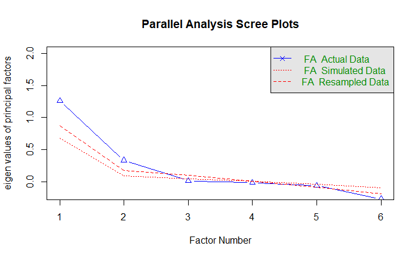

```r
df %>%
  select(
    #SEGM_AL_medRT_train,
    #SEGM_AL_medRT_TRN3_RND4,
    #SEGM_AL_medRT_RND4_REC5,
    #SEGM_AL_ACC_train,
    #SEGM_AL_ACC_TRN3_RND4,
    #SEGM_AL_ACC_RND4_REC5,
    SEGM_AL_2AFC_bigram,
    SEGM_AL_2AFC_trigram,
    SEGM_AL_SEGM_prod_data,
    #AGL_ACC_train,
    AGL_2AFC_phr,
    AGL_2AFC_sent,
    AGL_prod
  ) %>%
    fa.parallel(fm = "ml", fa = "fa")
```

The Eigenvalue suggests extracting only one factor despite the parallel analysis.

```r
SL_EFA = df %>%
  select(
    #SEGM_AL_medRT_train,
    #SEGM_AL_medRT_TRN3_RND4,
    #SEGM_AL_medRT_RND4_REC5,
    #SEGM_AL_ACC_train,
    #SEGM_AL_ACC_TRN3_RND4,
    #SEGM_AL_ACC_RND4_REC5,
    SEGM_AL_2AFC_bigram,
    SEGM_AL_2AFC_trigram,
    SEGM_AL_SEGM_prod_data,
    #AGL_ACC_train,
    AGL_2AFC_phr,
    AGL_2AFC_sent,
    AGL_prod
  ) %>%
  # maximum likelihood
  fa(
    nfactors = 1,
    fm = "ml",
    rotate = "Promax",
    use = "pairwise",
    cor = "cor",
    scores = "regression",
    missing = TRUE,
    impute = "mean"
    )
```

```r
summary(SL_EFA)
```

```r
SL_EFA$loadings
```

```
Loadings:
                       ML1
SEGM_AL_2AFC_bigram    0.261
SEGM_AL_2AFC_trigram   0.386
SEGM_AL_SEGM_prod_data 0.444
AGL_2AFC_phr           0.394
AGL_2AFC_sent          0.618
AGL_prod               0.553

                 ML1
SS loadings    1.256
Proportion Var 0.209
```

```r
tidy(SL_EFA$uniquenesses)
```

| names | x |
| --- | --- |
| SEGM_AL_2AFC_bigram | 0.9318427 |
| SEGM_AL_2AFC_trigram | 0.8513650 |
| SEGM_AL_SEGM_prod_data | 0.8026494 |
| AGL_2AFC_phr | 0.8449312 |
| AGL_2AFC_sent | 0.6185762 |
| AGL_prod | 0.6945337 |

```r
SL_model =
  "
  SL_offline =~ SEGM_AL_2AFC_trigram + SEGM_AL_SEGM_prod_data + AGL_2AFC_phr + AGL_2AFC_sent + AGL_prod + SEGM_AL_2AFC_bigram
  "
SL_fit = cfa(SL_model, df, missing = "ML", estimator = "MLR")
summary(SL_fit, standardized = TRUE, rsquare = TRUE, fit.measures = TRUE)
```

```
lavaan 0.6.16 ended normally after 33 iterations

  Estimator                                         ML
  Optimization method                           NLMINB
  Number of model parameters                        18

                                                  Used       Total
  Number of observations                           386         608
  Number of missing patterns                         4

Model Test User Model:
                                              Standard      Scaled
  Test Statistic                                27.602      28.693
  Degrees of freedom                                 9           9
  P-value (Chi-square)                           0.001       0.001
  Scaling correction factor                                  0.962
    Yuan-Bentler correction (Mplus variant)

Model Test Baseline Model:

  Test statistic                               143.804     143.553
  Degrees of freedom                                15          15
  P-value                                        0.000       0.000
  Scaling correction factor                                  1.002

User Model versus Baseline Model:

  Comparative Fit Index (CFI)                    0.856       0.847
  Tucker-Lewis Index (TLI)                       0.759       0.745

  Robust Comparative Fit Index (CFI)                         0.800
  Robust Tucker-Lewis Index (TLI)                            0.667

Loglikelihood and Information Criteria:

  Loglikelihood user model (H0)              -2241.817   -2241.817
  Scaling correction factor                                  0.970
      for the MLR correction
  Loglikelihood unrestricted model (H1)      -2228.016   -2228.016
  Scaling correction factor                                  0.967
```

[output cut: 53 more lines]

```
   .SEGM_AL_SEGM__    0.749    0.074   10.090    0.000    0.749    0.813
   .AGL_2AFC_phr      0.820    0.073   11.202    0.000    0.820    0.845
   .AGL_2AFC_sent     0.633    0.082    7.727    0.000    0.633    0.643
   .AGL_prod          0.647    0.091    7.104    0.000    0.647    0.663
   .SEGM_AL_2AFC_b    0.876    0.085   10.302    0.000    0.876    0.868
    SL_offline        0.246    0.098    2.515    0.012    1.000    1.000

R-Square:
                   Estimate
    SEGM_AL_2AFC_t    0.233
    SEGM_AL_SEGM__    0.187
    AGL_2AFC_phr      0.155
    AGL_2AFC_sent     0.357
    AGL_prod          0.337
    SEGM_AL_2AFC_b    0.132
```

```r
reliability(SL_fit)
```

```
       SL_offline
alpha   0.5890480
omega   0.6383944
omega2  0.6383944
omega3  0.6916696
avevar  0.2335218
```

```r
SL_EFA_sent = df %>%
  select(
    #SEGM_AL_medRT_train,
    #SEGM_AL_medRT_TRN3_RND4,
    #SEGM_AL_medRT_RND4_REC5,
    #SEGM_AL_ACC_train,
    #SEGM_AL_ACC_TRN3_RND4,
    #SEGM_AL_ACC_RND4_REC5,
    #SEGM_AL_2AFC_bigram,
    #SEGM_AL_2AFC_trigram,
    #SEGM_AL_SEGM_prod_data,
    #AGL_ACC_train,
    #AGL_2AFC_phr,
    AGL_2AFC_sent,
    AGL_prod
  ) %>%
  # maximum likelihood
  fa(
    nfactors = 1,
    fm = "ml",
    rotate = "Promax",
    use = "pairwise",
    cor = "cor",
    scores = "regression",
    missing = TRUE,
    impute = "mean"
    )
```

```r
summary(SL_EFA_sent)
```

```r
SL_EFA_sent$loadings
```

```
Loadings:
              ML1
AGL_2AFC_sent 0.623
AGL_prod      0.623

                 ML1
SS loadings    0.776
Proportion Var 0.388
```

```r
tidy(SL_EFA_sent$uniquenesses)
```

| names | x |
| --- | --- |
| AGL_2AFC_sent | 0.6118797 |
| AGL_prod | 0.6118797 |

We are happy because the uniquenesses are below threshold. Secondly, we check whether the remaining variables are able to form another distinct latent factor.

```r
SL_EFA_SEGM = df %>%
  select(
    SEGM_AL_2AFC_bigram,
    SEGM_AL_2AFC_trigram,
    SEGM_AL_SEGM_prod_data,
    AGL_2AFC_phr,
    #AGL_2AFC_sent,
    #AGL_prod
  ) %>%
  # maximum likelihood
  fa(
    nfactors = 1,
    fm = "ml",
    rotate = "Promax",
    use = "pairwise",
    cor = "cor",
    scores = "regression",
    missing = TRUE,
    impute = "mean"
    )
```

```r
summary(SL_EFA_SEGM)
```

```r
SL_EFA_SEGM$loadings
```

```
Loadings:
                       ML1
SEGM_AL_2AFC_bigram    0.469
SEGM_AL_2AFC_trigram   0.694
SEGM_AL_SEGM_prod_data 0.381
AGL_2AFC_phr           0.156

                 ML1
SS loadings    0.870
Proportion Var 0.218
```

```r
tidy(SL_EFA_SEGM$uniquenesses)
```

| names | x |
| --- | --- |
| SEGM_AL_2AFC_bigram | 0.7804586 |
| SEGM_AL_2AFC_trigram | 0.5185711 |
| SEGM_AL_SEGM_prod_data | 0.8548980 |
| AGL_2AFC_phr | 0.9757899 |

From the tables above, we can imply the possibility of SEGM_prod to form another factor. We should remove: - first the AGL_phrase - second either bigram or prod_data - data suggest that trigram and bigram are better though trigram and prod_data may be better kept due to theoretical implications. We examine the new two-factor model:

```r
SL_model_2factor =
  "
  SL_AGL =~ SEGM_AL_2AFC_trigram + SEGM_AL_SEGM_prod_data
  SL_SEGM =~ AGL_2AFC_sent + AGL_prod
  "
SL_fit_2factor = cfa(SL_model_2factor, df, missing = "ML", estimator = "MLR")
summary(SL_fit_2factor, standardized = TRUE, rsquare = TRUE, fit.measures = TRUE)
```

```
lavaan 0.6.16 ended normally after 33 iterations

  Estimator                                         ML
  Optimization method                           NLMINB
  Number of model parameters                        13

                                                  Used       Total
  Number of observations                           386         608
  Number of missing patterns                         4

Model Test User Model:
                                              Standard      Scaled
  Test Statistic                                 1.302       1.683
  Degrees of freedom                                 1           1
  P-value (Chi-square)                           0.254       0.194
  Scaling correction factor                                  0.774
    Yuan-Bentler correction (Mplus variant)

Model Test Baseline Model:

  Test statistic                                79.953      82.795
  Degrees of freedom                                 6           6
  P-value                                        0.000       0.000
  Scaling correction factor                                  0.966

User Model versus Baseline Model:

  Comparative Fit Index (CFI)                    0.996       0.991
  Tucker-Lewis Index (TLI)                       0.975       0.947

  Robust Comparative Fit Index (CFI)                         0.991
  Robust Tucker-Lewis Index (TLI)                            0.948

Loglikelihood and Information Criteria:

  Loglikelihood user model (H0)              -1491.792   -1491.792
  Scaling correction factor                                  0.947
      for the MLR correction
  Loglikelihood unrestricted model (H1)      -1491.141   -1491.141
  Scaling correction factor                                  0.934
```

[output cut: 53 more lines]

```
Variances:
                   Estimate  Std.Err  z-value  P(>|z|)   Std.lv  Std.all
   .SEGM_AL_2AFC_t    0.851    0.121    7.059    0.000    0.851    0.807
   .SEGM_AL_SEGM__    0.592    0.170    3.489    0.000    0.592    0.643
   .AGL_2AFC_sent     0.521    0.213    2.448    0.014    0.521    0.534
   .AGL_prod          0.655    0.157    4.164    0.000    0.655    0.677
    SL_AGL            0.204    0.106    1.916    0.055    1.000    1.000
    SL_SEGM           0.454    0.218    2.083    0.037    1.000    1.000

R-Square:
                   Estimate
    SEGM_AL_2AFC_t    0.193
    SEGM_AL_SEGM__    0.357
    AGL_2AFC_sent     0.466
    AGL_prod          0.323
```

```r
reliability(SL_fit_2factor)
```

```
          SL_AGL   SL_SEGM
alpha  0.4152094 0.5590772
omega  0.4210156 0.5640180
omega2 0.4210156 0.5640180
omega3 0.4208370 0.5638946
avevar 0.2693797 0.3948338
```

We can compare the R-square values:

1-factor model:

```
               Estimate
SEGM_AL_2AFC_t    0.233
SEGM_AL_SEGM__    0.187
AGL_2AFC_phr      0.155
AGL_2AFC_sent     0.357
AGL_prod          0.337
SEGM_AL_2AFC_b    0.132
```

2-factor model:

```
               Estimate
SEGM_AL_2AFC_t    0.193
SEGM_AL_SEGM__    0.357
AGL_2AFC_sent     0.466
AGL_prod          0.323
```